# Hierarhical Models with Ternary Latent Variable

### Optimal power

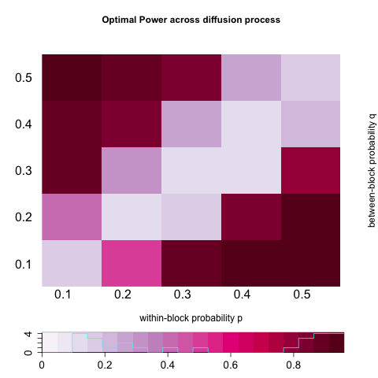

### Discrepancy between local and global scale

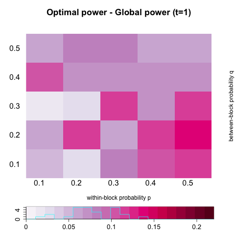

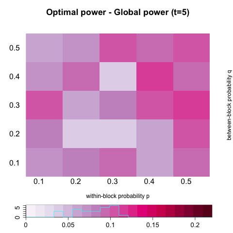

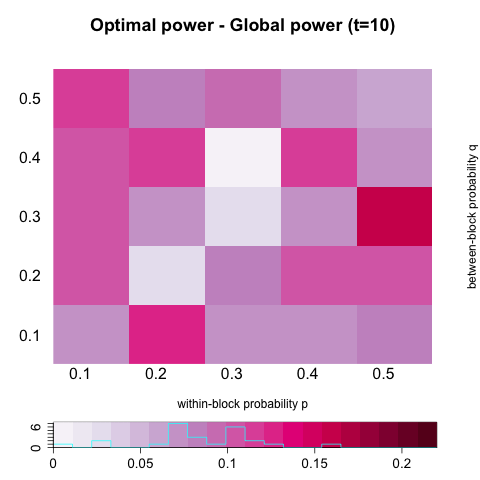

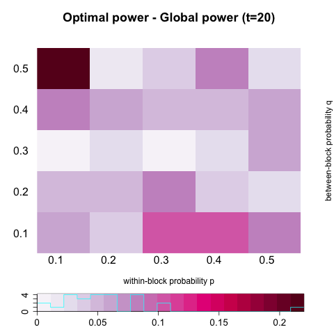

### Diffusion Process

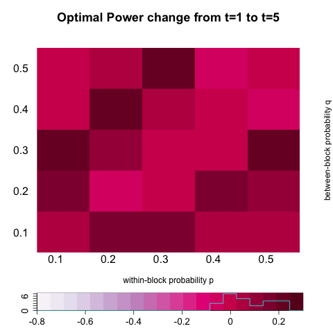

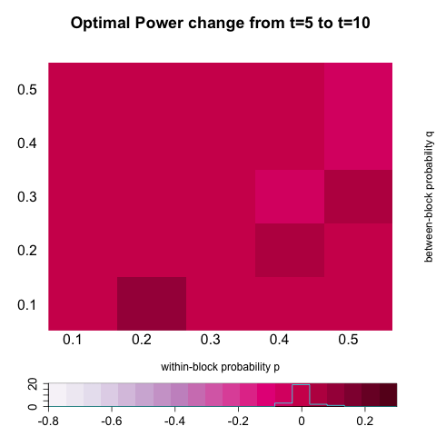

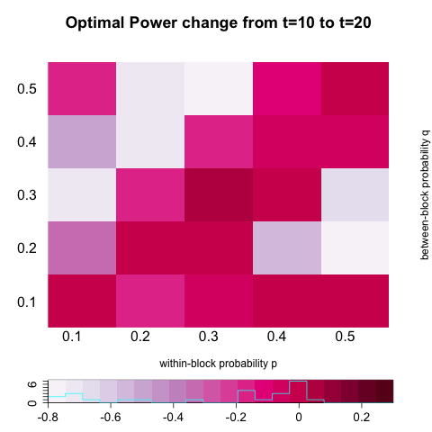

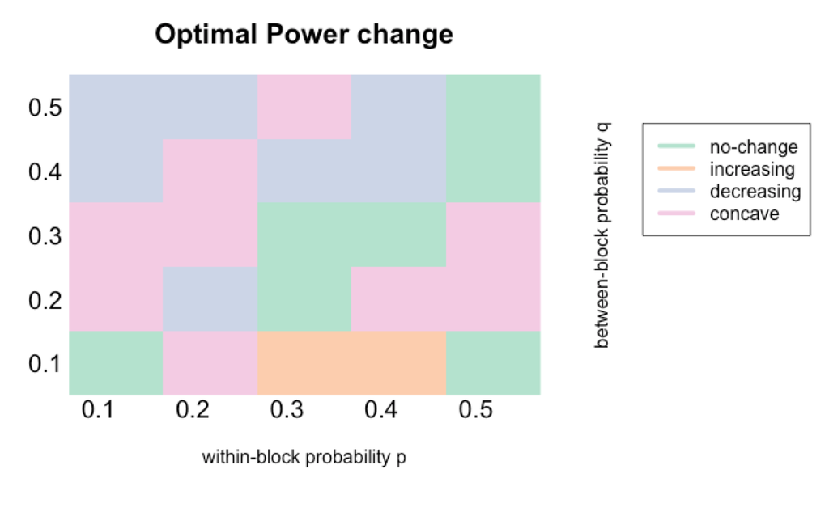

## Summary 2

$X_{i} \overset{i.i.d}{\sim} Multinorm(1/3, 1/3, 1/3), i = 1, ... ,n.$

$Z_{i} | X_{i} \overset{i.i.d}{\sim} \left\{ \begin{array}{cc} Multinorm(1/2, 1/4, 1/4) & X_{i} = 1 \\ Multinorm(1/4, 1/2, 1/4) & X_{i} = 2 \\ Multinorm(1/4, 1/4, 1/2) & X_{i} = 3 \end{array} \right.$

$A_{G} \sim Bern \left[ \begin{array}{c|c|c} \color{red}{p} & r & r \\ \hline r & \color{red}{p} & r \\ \hline r & r & r \end{array} \right]$

### Power heatmaps

- Global Power

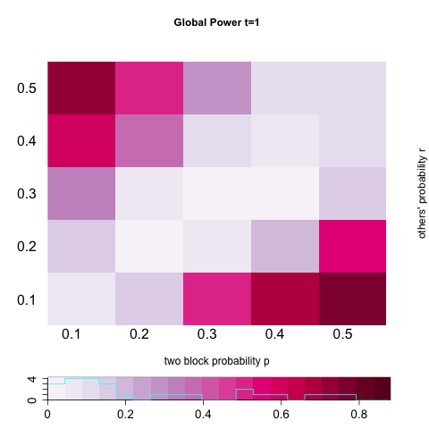

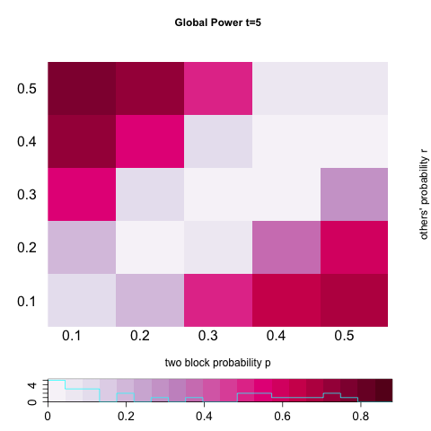

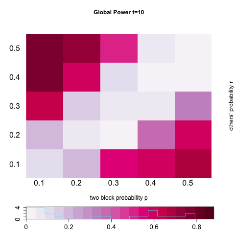

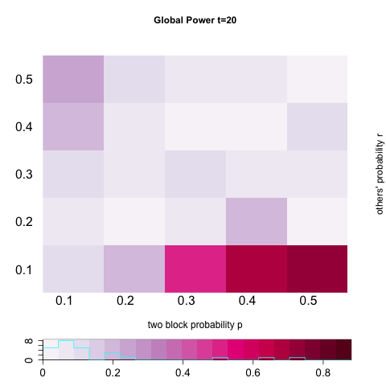

- Optimal Power

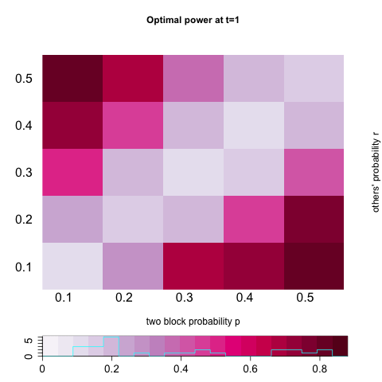

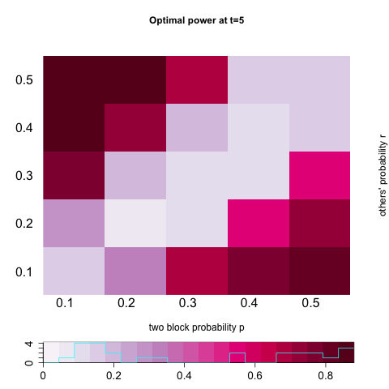

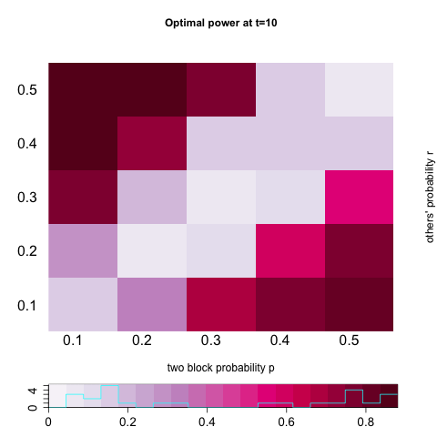

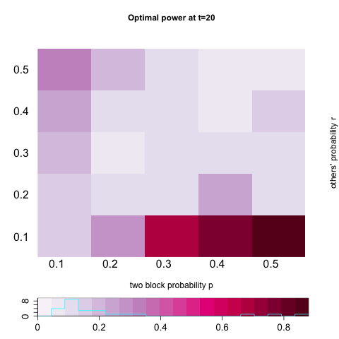

### Optimal power

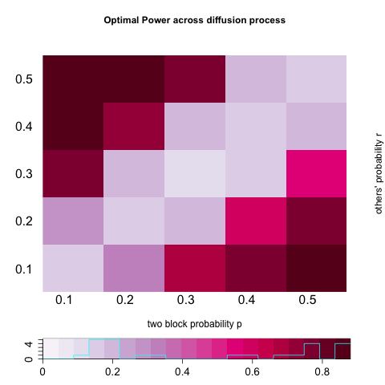

### Discrepancy between local and global scale

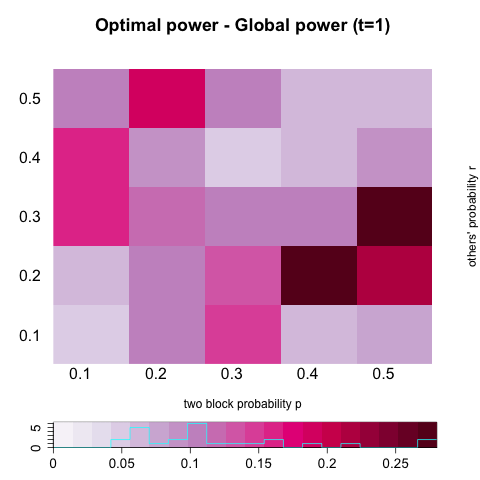

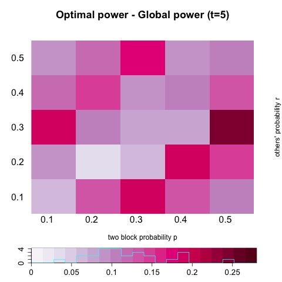

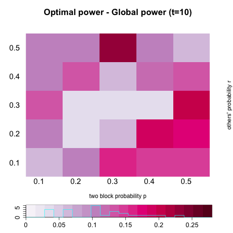

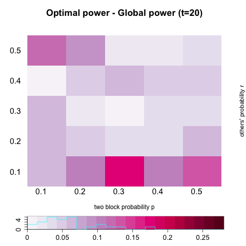

### Diffusion Process

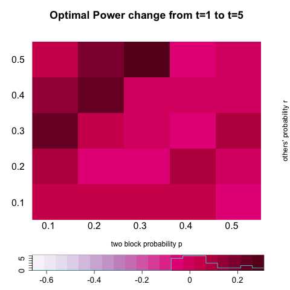

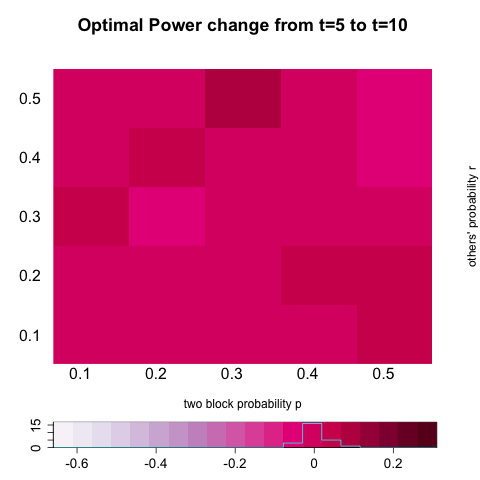

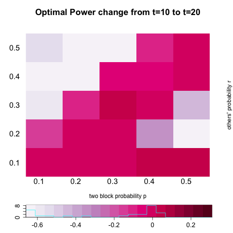

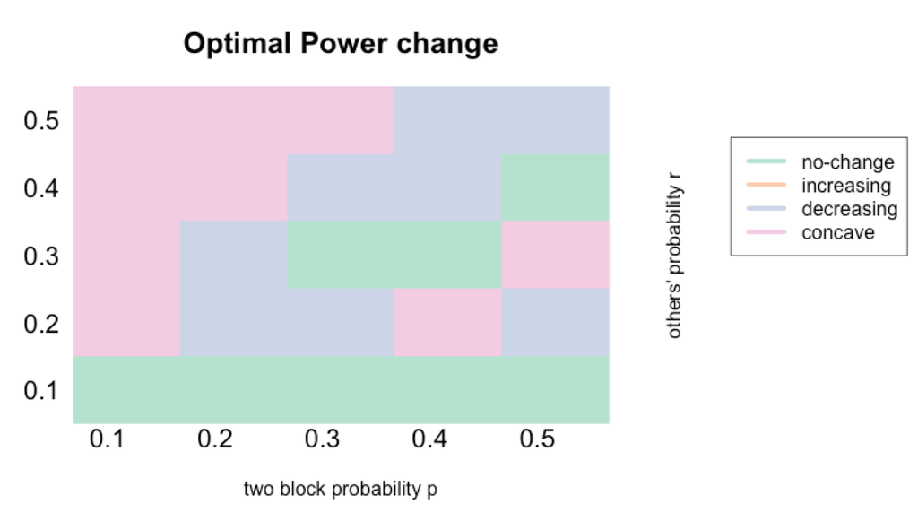